# EDA

```python
import numpy as np # Linear algebra.
import pandas as pd # Data processing, CSV file I/O (e.g. pd.read_csv).
import os
from glob import glob

%matplotlib inline
import matplotlib.pyplot as plt
import matplotlib.image as mpimg # Read png files.

# Set the plotting style of figures.
plt.style.use('ggplot')

# Plotting pretty figures and avoid blurry images.
%config InlineBackend.figure_format='retina'

import seaborn as sns

## Import any other packages you may need here.
import math
import random

from itertools import chain
from skimage.io import imread, imshow

import scipy
from scipy.ndimage import gaussian_filter
```

```python
RND_STATE = 42 # Random state used for reproducibility.

# Randomly sample the train_neg_sample list to be of the same length as train_pos_inds.
# Use the seed function for reproducibility.
random.seed(RND_STATE)
```

```python
## Below is some helper code to read all of your full image filepaths into a dataframe for easier manipulation.

all_xray_df = pd.read_csv('./data/Data_Entry_2017.csv')
all_xray_df.sample(10, random_state=RND_STATE)
```

|  | Image Index | Finding Labels | Follow-up # | Patient ID | Patient Age | Patient Gender | View Position | OriginalImage[Width | Height] | OriginalImagePixelSpacing[x | y] | Unnamed: 11 |
| --- | --- | --- | --- | --- | --- | --- | --- | --- | --- | --- | --- | --- |
| 89645 | 00022260_003.png | No Finding | 3 | 22260 | 54 | F | PA | 2542 | 2434 | 0.143000 | 0.143000 | NaN |
| 47446 | 00012048_007.png | Infiltration\|Mass\|Nodule | 7 | 12048 | 65 | M | AP | 2500 | 2048 | 0.168000 | 0.168000 | NaN |
| 57963 | 00014352_005.png | No Finding | 5 | 14352 | 6 | M | PA | 2992 | 2033 | 0.143000 | 0.143000 | NaN |
| 22863 | 00006040_001.png | No Finding | 1 | 6040 | 18 | F | AP | 2500 | 2048 | 0.171000 | 0.171000 | NaN |
| 43431 | 00011202_002.png | No Finding | 2 | 11202 | 19 | M | AP | 2500 | 2048 | 0.168000 | 0.168000 | NaN |
| 8601 | 00002275_007.png | Emphysema\|Infiltration\|Pneumothorax | 7 | 2275 | 62 | M | PA | 2500 | 2048 | 0.171000 | 0.171000 | NaN |
| 13260 | 00003446_008.png | No Finding | 8 | 3446 | 49 | M | AP | 2500 | 2048 | 0.171000 | 0.171000 | NaN |
| 111184 | 00030350_000.png | Atelectasis | 0 | 30350 | 24 | M | PA | 2021 | 2020 | 0.194311 | 0.194311 | NaN |
| 17284 | 00004640_000.png | No Finding | 0 | 4640 | 37 | F | PA | 2048 | 2500 | 0.171000 | 0.171000 | NaN |
| 33809 | 00008858_007.png | Effusion | 7 | 8858 | 49 | F | AP | 2500 | 2048 | 0.168000 | 0.168000 | NaN |

```python
data_sample = pd.read_csv('./data/sample_labels.csv')
data_sample.sample(10, random_state=RND_STATE)
```

|  | Image Index | Finding Labels | Follow-up # | Patient ID | Patient Age | Patient Gender | View Position | OriginalImageWidth | OriginalImageHeight | OriginalImagePixelSpacing_x | OriginalImagePixelSpacing_y |
| --- | --- | --- | --- | --- | --- | --- | --- | --- | --- | --- | --- |
| 2146 | 00011065_007.png | No Finding | 7 | 11065 | 066Y | M | PA | 2992 | 2991 | 0.143 | 0.143 |
| 1879 | 00009892_001.png | No Finding | 1 | 9892 | 062Y | F | PA | 2992 | 2991 | 0.143 | 0.143 |
| 346 | 00001836_076.png | Mass\|Nodule | 76 | 1836 | 050Y | F | AP | 2500 | 2048 | 0.168 | 0.168 |
| 2240 | 00011520_002.png | No Finding | 2 | 11520 | 049Y | M | AP | 2500 | 2048 | 0.168 | 0.168 |
| 1419 | 00007354_020.png | Consolidation\|Mass | 20 | 7354 | 043Y | M | AP | 2500 | 2048 | 0.168 | 0.168 |
| 5246 | 00028147_000.png | No Finding | 0 | 28147 | 063Y | M | PA | 2986 | 2991 | 0.143 | 0.143 |
| 730 | 00003837_008.png | No Finding | 8 | 3837 | 052Y | F | PA | 2500 | 2048 | 0.168 | 0.168 |
| 705 | 00003675_000.png | Fibrosis | 0 | 3675 | 070Y | F | PA | 2048 | 2500 | 0.168 | 0.168 |
| 1231 | 00006499_007.png | No Finding | 7 | 6499 | 034Y | M | PA | 2710 | 2991 | 0.143 | 0.143 |
| 3035 | 00014918_010.png | No Finding | 10 | 14918 | 045Y | M | PA | 2992 | 2991 | 0.143 | 0.143 |

EDA is open-ended, and it is up to you to decide how to look at different ways to slice and dice your data. A good starting point is to look at the requirements for the FDA documentation in the final part of this project to guide (some) of the analyses you do.

This EDA should also help to inform you of how pneumonia looks in the wild. E.g. what other types of diseases it's commonly found with, how often it is found, what ages it affects, etc.

Note that this NIH dataset was not specifically acquired for pneumonia. So, while this is a representation of 'pneumonia in the wild,' the prevalence of pneumonia may be different if you were to take only chest x-rays that were acquired in an ER setting with suspicion of pneumonia.

Perform the following EDA:

- The patient demographic data such as gender, age, patient position,etc. (as it is available)
- The x-ray views taken (i.e. view position)
- The number of cases including:
  - number of pneumonia cases,
  - number of non-pneumonia cases
- The distribution of other diseases that are comorbid with pneumonia
- Number of disease per patient
- Pixel-level assessments of the imaging data for healthy & disease states of interest (e.g. histograms of intensity values) and compare distributions across diseases.

Note: use full NIH data to perform the first a few EDA items and use `sample_labels.csv` for the pixel-level assassements.

Also, **describe your findings and how will you set up the model training based on the findings.**

# EDA TODOs

```python
pd.set_option('display.max_columns', None)
all_xray_df.head(10)
```

|  | Image Index | Finding Labels | Follow-up # | Patient ID | Patient Age | Patient Gender | View Position | OriginalImage[Width | Height] | OriginalImagePixelSpacing[x | y] | Unnamed: 11 |
| --- | --- | --- | --- | --- | --- | --- | --- | --- | --- | --- | --- | --- |
| 0 | 00000001_000.png | Cardiomegaly | 0 | 1 | 58 | M | PA | 2682 | 2749 | 0.143 | 0.143 | NaN |
| 1 | 00000001_001.png | Cardiomegaly\|Emphysema | 1 | 1 | 58 | M | PA | 2894 | 2729 | 0.143 | 0.143 | NaN |
| 2 | 00000001_002.png | Cardiomegaly\|Effusion | 2 | 1 | 58 | M | PA | 2500 | 2048 | 0.168 | 0.168 | NaN |
| 3 | 00000002_000.png | No Finding | 0 | 2 | 81 | M | PA | 2500 | 2048 | 0.171 | 0.171 | NaN |
| 4 | 00000003_000.png | Hernia | 0 | 3 | 81 | F | PA | 2582 | 2991 | 0.143 | 0.143 | NaN |
| 5 | 00000003_001.png | Hernia | 1 | 3 | 74 | F | PA | 2500 | 2048 | 0.168 | 0.168 | NaN |
| 6 | 00000003_002.png | Hernia | 2 | 3 | 75 | F | PA | 2048 | 2500 | 0.168 | 0.168 | NaN |
| 7 | 00000003_003.png | Hernia\|Infiltration | 3 | 3 | 76 | F | PA | 2698 | 2991 | 0.143 | 0.143 | NaN |
| 8 | 00000003_004.png | Hernia | 4 | 3 | 77 | F | PA | 2500 | 2048 | 0.168 | 0.168 | NaN |
| 9 | 00000003_005.png | Hernia | 5 | 3 | 78 | F | PA | 2686 | 2991 | 0.143 | 0.143 | NaN |

```python
## Transform 'Finding Labels' to one additional column per disease.
all_labels = np.unique(list(chain(*all_xray_df['Finding Labels'].map(lambda x: x.split('|')).tolist())))

## Assign 0 or 1 for the presence of a disease.
all_labels = [x for x in all_labels if len(x) > 0]

all_labels
```

```
['Atelectasis',
 'Cardiomegaly',
 'Consolidation',
 'Edema',
 'Effusion',
 'Emphysema',
 'Fibrosis',
 'Hernia',
 'Infiltration',
 'Mass',
 'No Finding',
 'Nodule',
 'Pleural_Thickening',
 'Pneumonia',
 'Pneumothorax']
```

```python
for label in all_labels:
    if len(label)>1:
        all_xray_df[label] = all_xray_df['Finding Labels'].map(lambda finding: 1. if label in finding else 0)

all_xray_df.head(10)
```

|  | Image Index | Finding Labels | Follow-up # | Patient ID | Patient Age | Patient Gender | View Position | OriginalImage[Width | Height] | OriginalImagePixelSpacing[x | y] | Unnamed: 11 | Atelectasis | Cardiomegaly | Consolidation | Edema | Effusion | Emphysema | Fibrosis | Hernia | Infiltration | Mass | No Finding | Nodule | Pleural_Thickening | Pneumonia | Pneumothorax |
| --- | --- | --- | --- | --- | --- | --- | --- | --- | --- | --- | --- | --- | --- | --- | --- | --- | --- | --- | --- | --- | --- | --- | --- | --- | --- | --- | --- |
| 0 | 00000001_000.png | Cardiomegaly | 0 | 1 | 58 | M | PA | 2682 | 2749 | 0.143 | 0.143 | NaN | 0.0 | 1.0 | 0.0 | 0.0 | 0.0 | 0.0 | 0.0 | 0.0 | 0.0 | 0.0 | 0.0 | 0.0 | 0.0 | 0.0 | 0.0 |
| 1 | 00000001_001.png | Cardiomegaly\|Emphysema | 1 | 1 | 58 | M | PA | 2894 | 2729 | 0.143 | 0.143 | NaN | 0.0 | 1.0 | 0.0 | 0.0 | 0.0 | 1.0 | 0.0 | 0.0 | 0.0 | 0.0 | 0.0 | 0.0 | 0.0 | 0.0 | 0.0 |
| 2 | 00000001_002.png | Cardiomegaly\|Effusion | 2 | 1 | 58 | M | PA | 2500 | 2048 | 0.168 | 0.168 | NaN | 0.0 | 1.0 | 0.0 | 0.0 | 1.0 | 0.0 | 0.0 | 0.0 | 0.0 | 0.0 | 0.0 | 0.0 | 0.0 | 0.0 | 0.0 |
| 3 | 00000002_000.png | No Finding | 0 | 2 | 81 | M | PA | 2500 | 2048 | 0.171 | 0.171 | NaN | 0.0 | 0.0 | 0.0 | 0.0 | 0.0 | 0.0 | 0.0 | 0.0 | 0.0 | 0.0 | 1.0 | 0.0 | 0.0 | 0.0 | 0.0 |
| 4 | 00000003_000.png | Hernia | 0 | 3 | 81 | F | PA | 2582 | 2991 | 0.143 | 0.143 | NaN | 0.0 | 0.0 | 0.0 | 0.0 | 0.0 | 0.0 | 0.0 | 1.0 | 0.0 | 0.0 | 0.0 | 0.0 | 0.0 | 0.0 | 0.0 |
| 5 | 00000003_001.png | Hernia | 1 | 3 | 74 | F | PA | 2500 | 2048 | 0.168 | 0.168 | NaN | 0.0 | 0.0 | 0.0 | 0.0 | 0.0 | 0.0 | 0.0 | 1.0 | 0.0 | 0.0 | 0.0 | 0.0 | 0.0 | 0.0 | 0.0 |
| 6 | 00000003_002.png | Hernia | 2 | 3 | 75 | F | PA | 2048 | 2500 | 0.168 | 0.168 | NaN | 0.0 | 0.0 | 0.0 | 0.0 | 0.0 | 0.0 | 0.0 | 1.0 | 0.0 | 0.0 | 0.0 | 0.0 | 0.0 | 0.0 | 0.0 |
| 7 | 00000003_003.png | Hernia\|Infiltration | 3 | 3 | 76 | F | PA | 2698 | 2991 | 0.143 | 0.143 | NaN | 0.0 | 0.0 | 0.0 | 0.0 | 0.0 | 0.0 | 0.0 | 1.0 | 1.0 | 0.0 | 0.0 | 0.0 | 0.0 | 0.0 | 0.0 |
| 8 | 00000003_004.png | Hernia | 4 | 3 | 77 | F | PA | 2500 | 2048 | 0.168 | 0.168 | NaN | 0.0 | 0.0 | 0.0 | 0.0 | 0.0 | 0.0 | 0.0 | 1.0 | 0.0 | 0.0 | 0.0 | 0.0 | 0.0 | 0.0 | 0.0 |
| 9 | 00000003_005.png | Hernia | 5 | 3 | 78 | F | PA | 2686 | 2991 | 0.143 | 0.143 | NaN | 0.0 | 0.0 | 0.0 | 0.0 | 0.0 | 0.0 | 0.0 | 1.0 | 0.0 | 0.0 | 0.0 | 0.0 | 0.0 | 0.0 | 0.0 |

```python
all_xray_df.describe()
```

|  | Follow-up # | Patient ID | Patient Age | OriginalImage[Width | Height] | OriginalImagePixelSpacing[x | y] | Unnamed: 11 | Atelectasis | Cardiomegaly | Consolidation | Edema | Effusion | Emphysema | Fibrosis | Hernia | Infiltration | Mass | No Finding | Nodule | Pleural_Thickening | Pneumonia | Pneumothorax |
| --- | --- | --- | --- | --- | --- | --- | --- | --- | --- | --- | --- | --- | --- | --- | --- | --- | --- | --- | --- | --- | --- | --- | --- |
| count | 112120.000000 | 112120.000000 | 112120.000000 | 112120.000000 | 112120.000000 | 112120.000000 | 112120.000000 | 0.0 | 112120.000000 | 112120.000000 | 112120.000000 | 112120.000000 | 112120.000000 | 112120.000000 | 112120.000000 | 112120.000000 | 112120.000000 | 112120.000000 | 112120.000000 | 112120.000000 | 112120.000000 | 112120.000000 | 112120.000000 |
| mean | 8.573751 | 14346.381743 | 46.901463 | 2646.078844 | 2486.438842 | 0.155649 | 0.155649 | NaN | 0.103095 | 0.024759 | 0.041625 | 0.020540 | 0.118775 | 0.022440 | 0.015037 | 0.002025 | 0.177435 | 0.051570 | 0.538361 | 0.056466 | 0.030191 | 0.012763 | 0.047289 |
| std | 15.406320 | 8403.876972 | 16.839923 | 341.246429 | 401.268227 | 0.016174 | 0.016174 | NaN | 0.304084 | 0.155391 | 0.199732 | 0.141841 | 0.323524 | 0.148111 | 0.121702 | 0.044950 | 0.382038 | 0.221158 | 0.498529 | 0.230821 | 0.171113 | 0.112251 | 0.212256 |
| min | 0.000000 | 1.000000 | 1.000000 | 1143.000000 | 966.000000 | 0.115000 | 0.115000 | NaN | 0.000000 | 0.000000 | 0.000000 | 0.000000 | 0.000000 | 0.000000 | 0.000000 | 0.000000 | 0.000000 | 0.000000 | 0.000000 | 0.000000 | 0.000000 | 0.000000 | 0.000000 |
| 25% | 0.000000 | 7310.750000 | 35.000000 | 2500.000000 | 2048.000000 | 0.143000 | 0.143000 | NaN | 0.000000 | 0.000000 | 0.000000 | 0.000000 | 0.000000 | 0.000000 | 0.000000 | 0.000000 | 0.000000 | 0.000000 | 0.000000 | 0.000000 | 0.000000 | 0.000000 | 0.000000 |
| 50% | 3.000000 | 13993.000000 | 49.000000 | 2518.000000 | 2544.000000 | 0.143000 | 0.143000 | NaN | 0.000000 | 0.000000 | 0.000000 | 0.000000 | 0.000000 | 0.000000 | 0.000000 | 0.000000 | 0.000000 | 0.000000 | 1.000000 | 0.000000 | 0.000000 | 0.000000 | 0.000000 |
| 75% | 10.000000 | 20673.000000 | 59.000000 | 2992.000000 | 2991.000000 | 0.168000 | 0.168000 | NaN | 0.000000 | 0.000000 | 0.000000 | 0.000000 | 0.000000 | 0.000000 | 0.000000 | 0.000000 | 0.000000 | 0.000000 | 1.000000 | 0.000000 | 0.000000 | 0.000000 | 0.000000 |
| max | 183.000000 | 30805.000000 | 414.000000 | 3827.000000 | 4715.000000 | 0.198800 | 0.198800 | NaN | 1.000000 | 1.000000 | 1.000000 | 1.000000 | 1.000000 | 1.000000 | 1.000000 | 1.000000 | 1.000000 | 1.000000 | 1.000000 | 1.000000 | 1.000000 | 1.000000 | 1.000000 |

```python
all_xray_df.info()
```

```
<class 'pandas.core.frame.DataFrame'>
RangeIndex: 112120 entries, 0 to 112119
Data columns (total 27 columns):
 #   Column                       Non-Null Count   Dtype
---  ------                       --------------   -----
 0   Image Index                  112120 non-null  object
 1   Finding Labels               112120 non-null  object
 2   Follow-up #                  112120 non-null  int64
 3   Patient ID                   112120 non-null  int64
 4   Patient Age                  112120 non-null  int64
 5   Patient Gender               112120 non-null  object
 6   View Position                112120 non-null  object
 7   OriginalImage[Width          112120 non-null  int64
 8   Height]                      112120 non-null  int64
 9   OriginalImagePixelSpacing[x  112120 non-null  float64
```

[output cut: 19 more lines]

```python
data_sample_df_paths = {os.path.basename(x): x for x in glob(
    os.path.join('./data', 'images*', '*', '*.png'))}

data_sample['path'] = data_sample['Image Index'].map(data_sample_df_paths.get)
data_sample.sample(10, random_state=RND_STATE)
```

|  | Image Index | Finding Labels | Follow-up # | Patient ID | Patient Age | Patient Gender | View Position | OriginalImageWidth | OriginalImageHeight | OriginalImagePixelSpacing_x | OriginalImagePixelSpacing_y | path |
| --- | --- | --- | --- | --- | --- | --- | --- | --- | --- | --- | --- | --- |
| 2146 | 00011065_007.png | No Finding | 7 | 11065 | 066Y | M | PA | 2992 | 2991 | 0.143 | 0.143 | ./data\images_005\images\00011065_007.png |
| 1879 | 00009892_001.png | No Finding | 1 | 9892 | 062Y | F | PA | 2992 | 2991 | 0.143 | 0.143 | ./data\images_005\images\00009892_001.png |
| 346 | 00001836_076.png | Mass\|Nodule | 76 | 1836 | 050Y | F | AP | 2500 | 2048 | 0.168 | 0.168 | ./data\images_002\images\00001836_076.png |
| 2240 | 00011520_002.png | No Finding | 2 | 11520 | 049Y | M | AP | 2500 | 2048 | 0.168 | 0.168 | ./data\images_005\images\00011520_002.png |
| 1419 | 00007354_020.png | Consolidation\|Mass | 20 | 7354 | 043Y | M | AP | 2500 | 2048 | 0.168 | 0.168 | ./data\images_004\images\00007354_020.png |
| 5246 | 00028147_000.png | No Finding | 0 | 28147 | 063Y | M | PA | 2986 | 2991 | 0.143 | 0.143 | ./data\images_011\images\00028147_000.png |
| 730 | 00003837_008.png | No Finding | 8 | 3837 | 052Y | F | PA | 2500 | 2048 | 0.168 | 0.168 | ./data\images_002\images\00003837_008.png |
| 705 | 00003675_000.png | Fibrosis | 0 | 3675 | 070Y | F | PA | 2048 | 2500 | 0.168 | 0.168 | ./data\images_002\images\00003675_000.png |
| 1231 | 00006499_007.png | No Finding | 7 | 6499 | 034Y | M | PA | 2710 | 2991 | 0.143 | 0.143 | ./data\images_003\images\00006499_007.png |
| 3035 | 00014918_010.png | No Finding | 10 | 14918 | 045Y | M | PA | 2992 | 2991 | 0.143 | 0.143 | ./data\images_007\images\00014918_010.png |

### Now we split the combined findings and append them as 'labels' to the data.

```python
findings = np.unique(list(chain(*all_xray_df['Finding Labels'].map(lambda x: x.split('|')).tolist())))
findings
```

```
array(['Atelectasis', 'Cardiomegaly', 'Consolidation', 'Edema',
       'Effusion', 'Emphysema', 'Fibrosis', 'Hernia', 'Infiltration',
       'Mass', 'No Finding', 'Nodule', 'Pleural_Thickening', 'Pneumonia',
       'Pneumothorax'], dtype='<U18')
```

```python
labels = [label for label in findings if label != 'No Finding']
labels
```

```
['Atelectasis',
 'Cardiomegaly',
 'Consolidation',
 'Edema',
 'Effusion',
 'Emphysema',
 'Fibrosis',
 'Hernia',
 'Infiltration',
 'Mass',
 'Nodule',
 'Pleural_Thickening',
 'Pneumonia',
 'Pneumothorax']
```

```python
for label in labels:
    all_xray_df[label] = all_xray_df['Finding Labels'].map(lambda finding: 1. if label in finding else 0)
    print(f'%s: %d'%(label, int(all_xray_df[label].sum())))
```

```
Atelectasis: 11559
Cardiomegaly: 2776
Consolidation: 4667
Edema: 2303
Effusion: 13317
Emphysema: 2516
Fibrosis: 1686
Hernia: 227
Infiltration: 19894
Mass: 5782
Nodule: 6331
Pleural_Thickening: 3385
Pneumonia: 1431
Pneumothorax: 5302
```

The dominant finding seems to be **Infiltration**. This is followed by **Effusion**, then **Atelectasis**, and so forth.

```python
all_xray_df.sample(10, random_state=RND_STATE)
```

|  | Image Index | Finding Labels | Follow-up # | Patient ID | Patient Age | Patient Gender | View Position | OriginalImage[Width | Height] | OriginalImagePixelSpacing[x | y] | Unnamed: 11 | Atelectasis | Cardiomegaly | Consolidation | Edema | Effusion | Emphysema | Fibrosis | Hernia | Infiltration | Mass | No Finding | Nodule | Pleural_Thickening | Pneumonia | Pneumothorax |
| --- | --- | --- | --- | --- | --- | --- | --- | --- | --- | --- | --- | --- | --- | --- | --- | --- | --- | --- | --- | --- | --- | --- | --- | --- | --- | --- | --- |
| 89645 | 00022260_003.png | No Finding | 3 | 22260 | 54 | F | PA | 2542 | 2434 | 0.143000 | 0.143000 | NaN | 0.0 | 0.0 | 0.0 | 0.0 | 0.0 | 0.0 | 0.0 | 0.0 | 0.0 | 0.0 | 1.0 | 0.0 | 0.0 | 0.0 | 0.0 |
| 47446 | 00012048_007.png | Infiltration\|Mass\|Nodule | 7 | 12048 | 65 | M | AP | 2500 | 2048 | 0.168000 | 0.168000 | NaN | 0.0 | 0.0 | 0.0 | 0.0 | 0.0 | 0.0 | 0.0 | 0.0 | 1.0 | 1.0 | 0.0 | 1.0 | 0.0 | 0.0 | 0.0 |
| 57963 | 00014352_005.png | No Finding | 5 | 14352 | 6 | M | PA | 2992 | 2033 | 0.143000 | 0.143000 | NaN | 0.0 | 0.0 | 0.0 | 0.0 | 0.0 | 0.0 | 0.0 | 0.0 | 0.0 | 0.0 | 1.0 | 0.0 | 0.0 | 0.0 | 0.0 |
| 22863 | 00006040_001.png | No Finding | 1 | 6040 | 18 | F | AP | 2500 | 2048 | 0.171000 | 0.171000 | NaN | 0.0 | 0.0 | 0.0 | 0.0 | 0.0 | 0.0 | 0.0 | 0.0 | 0.0 | 0.0 | 1.0 | 0.0 | 0.0 | 0.0 | 0.0 |
| 43431 | 00011202_002.png | No Finding | 2 | 11202 | 19 | M | AP | 2500 | 2048 | 0.168000 | 0.168000 | NaN | 0.0 | 0.0 | 0.0 | 0.0 | 0.0 | 0.0 | 0.0 | 0.0 | 0.0 | 0.0 | 1.0 | 0.0 | 0.0 | 0.0 | 0.0 |
| 8601 | 00002275_007.png | Emphysema\|Infiltration\|Pneumothorax | 7 | 2275 | 62 | M | PA | 2500 | 2048 | 0.171000 | 0.171000 | NaN | 0.0 | 0.0 | 0.0 | 0.0 | 0.0 | 1.0 | 0.0 | 0.0 | 1.0 | 0.0 | 0.0 | 0.0 | 0.0 | 0.0 | 1.0 |
| 13260 | 00003446_008.png | No Finding | 8 | 3446 | 49 | M | AP | 2500 | 2048 | 0.171000 | 0.171000 | NaN | 0.0 | 0.0 | 0.0 | 0.0 | 0.0 | 0.0 | 0.0 | 0.0 | 0.0 | 0.0 | 1.0 | 0.0 | 0.0 | 0.0 | 0.0 |
| 111184 | 00030350_000.png | Atelectasis | 0 | 30350 | 24 | M | PA | 2021 | 2020 | 0.194311 | 0.194311 | NaN | 1.0 | 0.0 | 0.0 | 0.0 | 0.0 | 0.0 | 0.0 | 0.0 | 0.0 | 0.0 | 0.0 | 0.0 | 0.0 | 0.0 | 0.0 |
| 17284 | 00004640_000.png | No Finding | 0 | 4640 | 37 | F | PA | 2048 | 2500 | 0.171000 | 0.171000 | NaN | 0.0 | 0.0 | 0.0 | 0.0 | 0.0 | 0.0 | 0.0 | 0.0 | 0.0 | 0.0 | 1.0 | 0.0 | 0.0 | 0.0 | 0.0 |
| 33809 | 00008858_007.png | Effusion | 7 | 8858 | 49 | F | AP | 2500 | 2048 | 0.168000 | 0.168000 | NaN | 0.0 | 0.0 | 0.0 | 0.0 | 1.0 | 0.0 | 0.0 | 0.0 | 0.0 | 0.0 | 0.0 | 0.0 | 0.0 | 0.0 | 0.0 |

## Exploring Patient Demographics

```python
all_xray_df['Patient Gender'].value_counts()
```

```
M    63340
F    48780
Name: Patient Gender, dtype: int64
```

```python
print('Number of Males in the data: {}'.format(all_xray_df['Patient Gender'][(all_xray_df['Patient Gender']=='M')].value_counts()))
print('Number of Females in the data: {}'.format(all_xray_df['Patient Gender'][(all_xray_df['Patient Gender']=='F')].value_counts()))
```

```
Number of Males in the data: M    63340
Name: Patient Gender, dtype: int64
Number of Females in the data: F    48780
Name: Patient Gender, dtype: int64
```

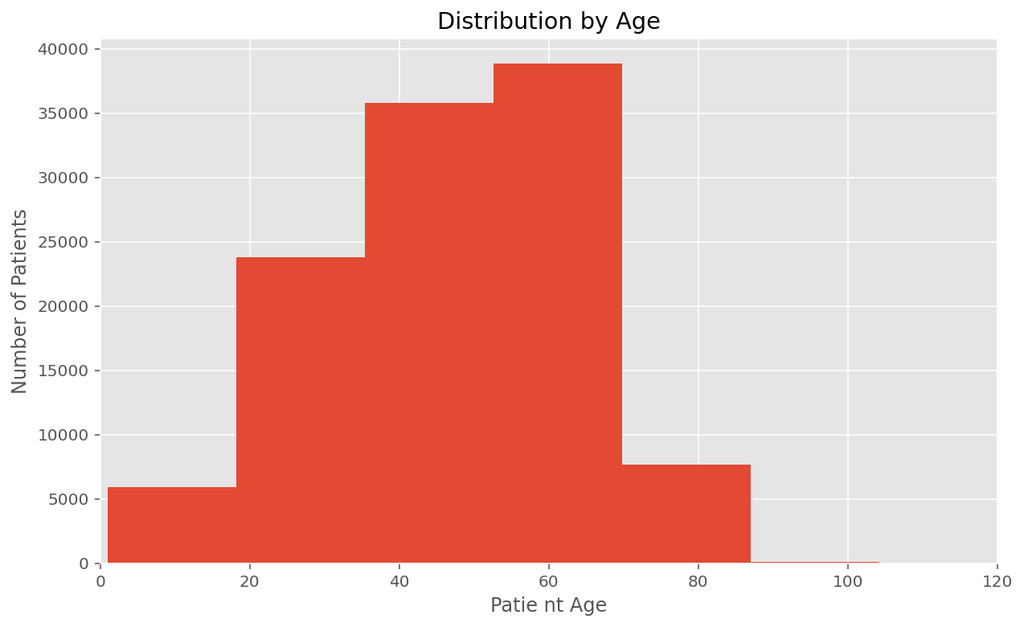

```python
# Exploring age distributions.
plt.figure(figsize=(10, 6))
plt.hist(all_xray_df['Patient Age'], bins=24)
plt.xlim(0, 120)
plt.title('Distribution by Age')
plt.xlabel('Patie nt Age')
plt.ylabel('Number of Patients')
plt.savefig('./out/EDA_Distribution_by_Age.png', dpi=300)
plt.show()
```

### Distribution by Gender

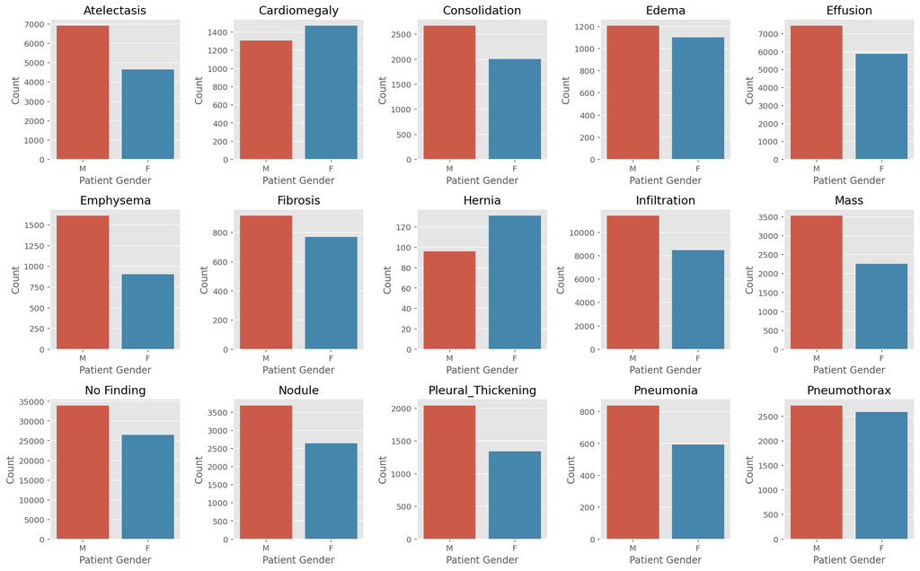

```python
fig = plt.subplots(figsize=(16, 10))
for i, label in enumerate(findings):
    plt.subplot(3, 5, i+1)
    plt.subplots_adjust(hspace=1.)
    ax = sns.countplot(
        x='Patient Gender',
        data=all_xray_df[all_xray_df[label]==1],
        order=['M', 'F'])
    plt.ylabel('Count')
    plt.title(label)
    plt.tight_layout()
plt.savefig('./out/EDA_Distribution_by_Gender.png', dpi=300)
```

```python
for label in findings:
    male_counts = all_xray_df[all_xray_df['Patient Gender']=='M'][label].sum()
    female_counts = all_xray_df[all_xray_df['Patient Gender']=='F'][label].sum()

    if male_counts < female_counts:
        print('%s: Predominately found in Females' % (label.upper()))

    elif male_counts > female_counts:
        print('%s: Predominately found in Males' % (label.upper()))

    else:
        print('%s: Equally found in both genders' % (label.upper()))
```

```
ATELECTASIS: Predominately found in Males
CARDIOMEGALY: Predominately found in Females
CONSOLIDATION: Predominately found in Males
EDEMA: Predominately found in Males
EFFUSION: Predominately found in Males
EMPHYSEMA: Predominately found in Males
FIBROSIS: Predominately found in Males
HERNIA: Predominately found in Females
INFILTRATION: Predominately found in Males
MASS: Predominately found in Males
NO FINDING: Predominately found in Males
NODULE: Predominately found in Males
PLEURAL_THICKENING: Predominately found in Males
PNEUMONIA: Predominately found in Males
PNEUMOTHORAX: Predominately found in Males
```

### Distribution by Age

```python
all_xray_df[all_xray_df['Patient Age'] < 100].describe()
```

|  | Follow-up # | Patient ID | Patient Age | OriginalImage[Width | Height] | OriginalImagePixelSpacing[x | y] | Unnamed: 11 | Atelectasis | Cardiomegaly | Consolidation | Edema | Effusion | Emphysema | Fibrosis | Hernia | Infiltration | Mass | No Finding | Nodule | Pleural_Thickening | Pneumonia | Pneumothorax |
| --- | --- | --- | --- | --- | --- | --- | --- | --- | --- | --- | --- | --- | --- | --- | --- | --- | --- | --- | --- | --- | --- | --- | --- |
| count | 112104.000000 | 112104.000000 | 112104.000000 | 112104.000000 | 112104.000000 | 112104.000000 | 112104.000000 | 0.0 | 112104.000000 | 112104.000000 | 112104.000000 | 112104.000000 | 112104.000000 | 112104.000000 | 112104.000000 | 112104.000000 | 112104.000000 | 112104.000000 | 112104.000000 | 112104.000000 | 112104.000000 | 112104.000000 | 112104.000000 |
| mean | 8.574172 | 14345.720724 | 46.872574 | 2646.035253 | 2486.393153 | 0.155651 | 0.155651 | NaN | 0.103101 | 0.024763 | 0.041631 | 0.020535 | 0.118783 | 0.022443 | 0.015040 | 0.002025 | 0.177433 | 0.051550 | 0.538366 | 0.056474 | 0.030186 | 0.012756 | 0.047286 |
| std | 15.406734 | 8403.980520 | 16.598152 | 341.243771 | 401.270806 | 0.016174 | 0.016174 | NaN | 0.304092 | 0.155402 | 0.199745 | 0.141820 | 0.323534 | 0.148121 | 0.121711 | 0.044954 | 0.382037 | 0.221118 | 0.498528 | 0.230836 | 0.171100 | 0.112220 | 0.212252 |
| min | 0.000000 | 1.000000 | 1.000000 | 1143.000000 | 966.000000 | 0.115000 | 0.115000 | NaN | 0.000000 | 0.000000 | 0.000000 | 0.000000 | 0.000000 | 0.000000 | 0.000000 | 0.000000 | 0.000000 | 0.000000 | 0.000000 | 0.000000 | 0.000000 | 0.000000 | 0.000000 |
| 25% | 0.000000 | 7308.000000 | 35.000000 | 2500.000000 | 2048.000000 | 0.143000 | 0.143000 | NaN | 0.000000 | 0.000000 | 0.000000 | 0.000000 | 0.000000 | 0.000000 | 0.000000 | 0.000000 | 0.000000 | 0.000000 | 0.000000 | 0.000000 | 0.000000 | 0.000000 | 0.000000 |
| 50% | 3.000000 | 13993.000000 | 49.000000 | 2518.000000 | 2544.000000 | 0.143000 | 0.143000 | NaN | 0.000000 | 0.000000 | 0.000000 | 0.000000 | 0.000000 | 0.000000 | 0.000000 | 0.000000 | 0.000000 | 0.000000 | 1.000000 | 0.000000 | 0.000000 | 0.000000 | 0.000000 |
| 75% | 10.000000 | 20673.000000 | 59.000000 | 2992.000000 | 2991.000000 | 0.168000 | 0.168000 | NaN | 0.000000 | 0.000000 | 0.000000 | 0.000000 | 0.000000 | 0.000000 | 0.000000 | 0.000000 | 0.000000 | 0.000000 | 1.000000 | 0.000000 | 0.000000 | 0.000000 | 0.000000 |
| max | 183.000000 | 30805.000000 | 95.000000 | 3827.000000 | 4715.000000 | 0.198800 | 0.198800 | NaN | 1.000000 | 1.000000 | 1.000000 | 1.000000 | 1.000000 | 1.000000 | 1.000000 | 1.000000 | 1.000000 | 1.000000 | 1.000000 | 1.000000 | 1.000000 | 1.000000 | 1.000000 |

```python
all_xray_df[all_xray_df['Patient Age'] > 100]
```

|  | Image Index | Finding Labels | Follow-up # | Patient ID | Patient Age | Patient Gender | View Position | OriginalImage[Width | Height] | OriginalImagePixelSpacing[x | y] | Unnamed: 11 | Atelectasis | Cardiomegaly | Consolidation | Edema | Effusion | Emphysema | Fibrosis | Hernia | Infiltration | Mass | No Finding | Nodule | Pleural_Thickening | Pneumonia | Pneumothorax |
| --- | --- | --- | --- | --- | --- | --- | --- | --- | --- | --- | --- | --- | --- | --- | --- | --- | --- | --- | --- | --- | --- | --- | --- | --- | --- | --- | --- |
| 20852 | 00005567_000.png | Effusion\|Pneumonia | 0 | 5567 | 412 | M | AP | 3056 | 2544 | 0.139 | 0.139 | NaN | 0.0 | 0.0 | 0.0 | 0.0 | 1.0 | 0.0 | 0.0 | 0.0 | 0.0 | 0.0 | 0.0 | 0.0 | 0.0 | 1.0 | 0.0 |
| 46965 | 00011973_002.png | Edema | 2 | 11973 | 414 | M | AP | 3056 | 2544 | 0.139 | 0.139 | NaN | 0.0 | 0.0 | 0.0 | 1.0 | 0.0 | 0.0 | 0.0 | 0.0 | 0.0 | 0.0 | 0.0 | 0.0 | 0.0 | 0.0 | 0.0 |
| 48284 | 00012238_010.png | No Finding | 10 | 12238 | 148 | M | PA | 2992 | 2991 | 0.143 | 0.143 | NaN | 0.0 | 0.0 | 0.0 | 0.0 | 0.0 | 0.0 | 0.0 | 0.0 | 0.0 | 0.0 | 1.0 | 0.0 | 0.0 | 0.0 | 0.0 |
| 55742 | 00013950_000.png | No Finding | 0 | 13950 | 148 | M | PA | 2964 | 2939 | 0.143 | 0.143 | NaN | 0.0 | 0.0 | 0.0 | 0.0 | 0.0 | 0.0 | 0.0 | 0.0 | 0.0 | 0.0 | 1.0 | 0.0 | 0.0 | 0.0 | 0.0 |
| 58650 | 00014520_026.png | Infiltration\|Mass | 26 | 14520 | 150 | M | PA | 2992 | 2991 | 0.143 | 0.143 | NaN | 0.0 | 0.0 | 0.0 | 0.0 | 0.0 | 0.0 | 0.0 | 0.0 | 1.0 | 1.0 | 0.0 | 0.0 | 0.0 | 0.0 | 0.0 |
| 62929 | 00015558_000.png | No Finding | 0 | 15558 | 149 | M | PA | 2992 | 2991 | 0.143 | 0.143 | NaN | 0.0 | 0.0 | 0.0 | 0.0 | 0.0 | 0.0 | 0.0 | 0.0 | 0.0 | 0.0 | 1.0 | 0.0 | 0.0 | 0.0 | 0.0 |
| 74884 | 00018366_044.png | Pneumothorax | 44 | 18366 | 152 | F | PA | 2302 | 2991 | 0.143 | 0.143 | NaN | 0.0 | 0.0 | 0.0 | 0.0 | 0.0 | 0.0 | 0.0 | 0.0 | 0.0 | 0.0 | 0.0 | 0.0 | 0.0 | 0.0 | 1.0 |
| 78795 | 00019346_000.png | Infiltration | 0 | 19346 | 151 | F | PA | 2678 | 2774 | 0.143 | 0.143 | NaN | 0.0 | 0.0 | 0.0 | 0.0 | 0.0 | 0.0 | 0.0 | 0.0 | 1.0 | 0.0 | 0.0 | 0.0 | 0.0 | 0.0 | 0.0 |
| 84810 | 00020900_002.png | No Finding | 2 | 20900 | 411 | M | AP | 3056 | 2544 | 0.139 | 0.139 | NaN | 0.0 | 0.0 | 0.0 | 0.0 | 0.0 | 0.0 | 0.0 | 0.0 | 0.0 | 0.0 | 1.0 | 0.0 | 0.0 | 0.0 | 0.0 |
| 85404 | 00021047_002.png | Mass\|Pleural_Thickening | 2 | 21047 | 412 | M | AP | 3056 | 2544 | 0.139 | 0.139 | NaN | 0.0 | 0.0 | 0.0 | 0.0 | 0.0 | 0.0 | 0.0 | 0.0 | 0.0 | 1.0 | 0.0 | 0.0 | 1.0 | 0.0 | 0.0 |
| 86264 | 00021275_003.png | No Finding | 3 | 21275 | 413 | F | AP | 3056 | 2544 | 0.139 | 0.139 | NaN | 0.0 | 0.0 | 0.0 | 0.0 | 0.0 | 0.0 | 0.0 | 0.0 | 0.0 | 0.0 | 1.0 | 0.0 | 0.0 | 0.0 | 0.0 |
| 91369 | 00022811_000.png | No Finding | 0 | 22811 | 412 | M | PA | 3056 | 2544 | 0.139 | 0.139 | NaN | 0.0 | 0.0 | 0.0 | 0.0 | 0.0 | 0.0 | 0.0 | 0.0 | 0.0 | 0.0 | 1.0 | 0.0 | 0.0 | 0.0 | 0.0 |
| 95794 | 00025206_000.png | Infiltration\|Mass | 0 | 25206 | 153 | M | PA | 2992 | 2991 | 0.143 | 0.143 | NaN | 0.0 | 0.0 | 0.0 | 0.0 | 0.0 | 0.0 | 0.0 | 0.0 | 1.0 | 1.0 | 0.0 | 0.0 | 0.0 | 0.0 | 0.0 |
| 98495 | 00026028_001.png | Atelectasis | 1 | 26028 | 154 | M | PA | 2992 | 2991 | 0.143 | 0.143 | NaN | 1.0 | 0.0 | 0.0 | 0.0 | 0.0 | 0.0 | 0.0 | 0.0 | 0.0 | 0.0 | 0.0 | 0.0 | 0.0 | 0.0 | 0.0 |
| 101194 | 00026871_000.png | No Finding | 0 | 26871 | 155 | F | PA | 2992 | 2991 | 0.143 | 0.143 | NaN | 0.0 | 0.0 | 0.0 | 0.0 | 0.0 | 0.0 | 0.0 | 0.0 | 0.0 | 0.0 | 1.0 | 0.0 | 0.0 | 0.0 | 0.0 |
| 104590 | 00027989_000.png | No Finding | 0 | 27989 | 155 | M | PA | 2992 | 2991 | 0.143 | 0.143 | NaN | 0.0 | 0.0 | 0.0 | 0.0 | 0.0 | 0.0 | 0.0 | 0.0 | 0.0 | 0.0 | 1.0 | 0.0 | 0.0 | 0.0 | 0.0 |

```python
## Adopting a so-called "cut-off" value of 120 years for the age demographic.
age_cut_off = all_xray_df[all_xray_df['Patient Age'] < 120]
age_cut_off.describe()
```

|  | Follow-up # | Patient ID | Patient Age | OriginalImage[Width | Height] | OriginalImagePixelSpacing[x | y] | Unnamed: 11 | Atelectasis | Cardiomegaly | Consolidation | Edema | Effusion | Emphysema | Fibrosis | Hernia | Infiltration | Mass | No Finding | Nodule | Pleural_Thickening | Pneumonia | Pneumothorax |
| --- | --- | --- | --- | --- | --- | --- | --- | --- | --- | --- | --- | --- | --- | --- | --- | --- | --- | --- | --- | --- | --- | --- | --- |
| count | 112104.000000 | 112104.000000 | 112104.000000 | 112104.000000 | 112104.000000 | 112104.000000 | 112104.000000 | 0.0 | 112104.000000 | 112104.000000 | 112104.000000 | 112104.000000 | 112104.000000 | 112104.000000 | 112104.000000 | 112104.000000 | 112104.000000 | 112104.000000 | 112104.000000 | 112104.000000 | 112104.000000 | 112104.000000 | 112104.000000 |
| mean | 8.574172 | 14345.720724 | 46.872574 | 2646.035253 | 2486.393153 | 0.155651 | 0.155651 | NaN | 0.103101 | 0.024763 | 0.041631 | 0.020535 | 0.118783 | 0.022443 | 0.015040 | 0.002025 | 0.177433 | 0.051550 | 0.538366 | 0.056474 | 0.030186 | 0.012756 | 0.047286 |
| std | 15.406734 | 8403.980520 | 16.598152 | 341.243771 | 401.270806 | 0.016174 | 0.016174 | NaN | 0.304092 | 0.155402 | 0.199745 | 0.141820 | 0.323534 | 0.148121 | 0.121711 | 0.044954 | 0.382037 | 0.221118 | 0.498528 | 0.230836 | 0.171100 | 0.112220 | 0.212252 |
| min | 0.000000 | 1.000000 | 1.000000 | 1143.000000 | 966.000000 | 0.115000 | 0.115000 | NaN | 0.000000 | 0.000000 | 0.000000 | 0.000000 | 0.000000 | 0.000000 | 0.000000 | 0.000000 | 0.000000 | 0.000000 | 0.000000 | 0.000000 | 0.000000 | 0.000000 | 0.000000 |
| 25% | 0.000000 | 7308.000000 | 35.000000 | 2500.000000 | 2048.000000 | 0.143000 | 0.143000 | NaN | 0.000000 | 0.000000 | 0.000000 | 0.000000 | 0.000000 | 0.000000 | 0.000000 | 0.000000 | 0.000000 | 0.000000 | 0.000000 | 0.000000 | 0.000000 | 0.000000 | 0.000000 |
| 50% | 3.000000 | 13993.000000 | 49.000000 | 2518.000000 | 2544.000000 | 0.143000 | 0.143000 | NaN | 0.000000 | 0.000000 | 0.000000 | 0.000000 | 0.000000 | 0.000000 | 0.000000 | 0.000000 | 0.000000 | 0.000000 | 1.000000 | 0.000000 | 0.000000 | 0.000000 | 0.000000 |
| 75% | 10.000000 | 20673.000000 | 59.000000 | 2992.000000 | 2991.000000 | 0.168000 | 0.168000 | NaN | 0.000000 | 0.000000 | 0.000000 | 0.000000 | 0.000000 | 0.000000 | 0.000000 | 0.000000 | 0.000000 | 0.000000 | 1.000000 | 0.000000 | 0.000000 | 0.000000 | 0.000000 |
| max | 183.000000 | 30805.000000 | 95.000000 | 3827.000000 | 4715.000000 | 0.198800 | 0.198800 | NaN | 1.000000 | 1.000000 | 1.000000 | 1.000000 | 1.000000 | 1.000000 | 1.000000 | 1.000000 | 1.000000 | 1.000000 | 1.000000 | 1.000000 | 1.000000 | 1.000000 | 1.000000 |

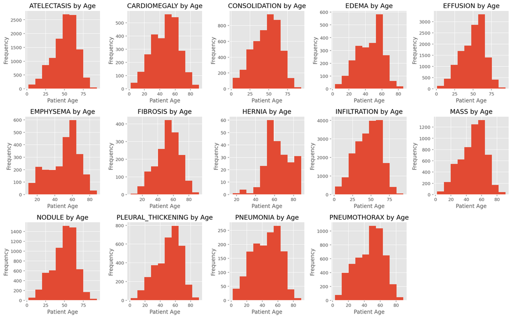

```python
## Age distribution for each disease.
fig = plt.subplots(figsize = (16, 10))
for i, label in enumerate(labels):
    plt.subplot(3, 5, i+1)
    plt.subplots_adjust(hspace=1.)
    plt.hist(age_cut_off[age_cut_off[label]==1.]['Patient Age'])
    plt.xlabel('Patient Age')
    plt.ylabel('Frequency')
    plt.title('{} by Age'.format(label.upper()))
    plt.tight_layout()
plt.savefig('./out/EDA_Age_Distribution_for_Each_Disease.png', dpi=300)
```

From the above plots we see the age ranging from 1yr – 95yrs old pretty-much *all* the disease labels mentioned above, having patients aging between 20yrs and 70yrs being the more dominant with *any* of the diseases. This finding excludes **Hernia**, which seems to have a rather different distribution when compared to the rest.

### Age Distribution for Each Disease by Gender

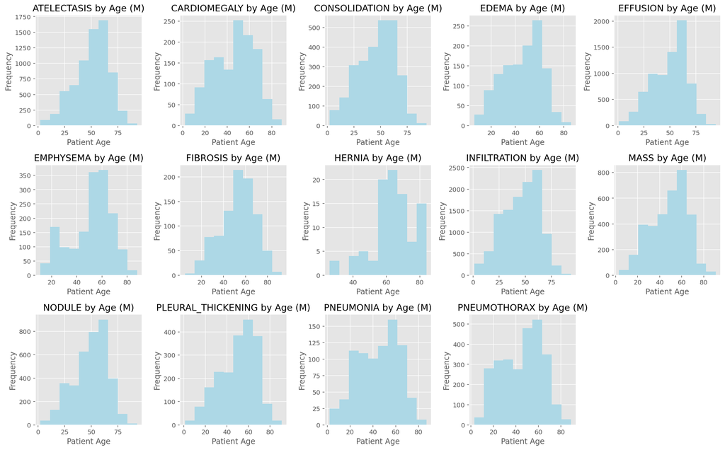

```python
## Age distribution for each disease for the male population.
fig = plt.subplots(figsize = (16, 10))
for i, label in enumerate(labels):
    plt.subplot(3, 5, i+1)
    plt.subplots_adjust(hspace=1.)
    plt.hist(age_cut_off[(age_cut_off[label]==1.) & (age_cut_off['Patient Gender'] == 'M')]['Patient Age'], color="lightblue")
    plt.xlabel('Patient Age')
    plt.ylabel('Frequency')
    plt.title('%s by Age (M)' % label.upper())
    plt.tight_layout()
plt.savefig('./out/EDA_Age_Distribution_for_Each_Disease_M.png', dpi=300)
```

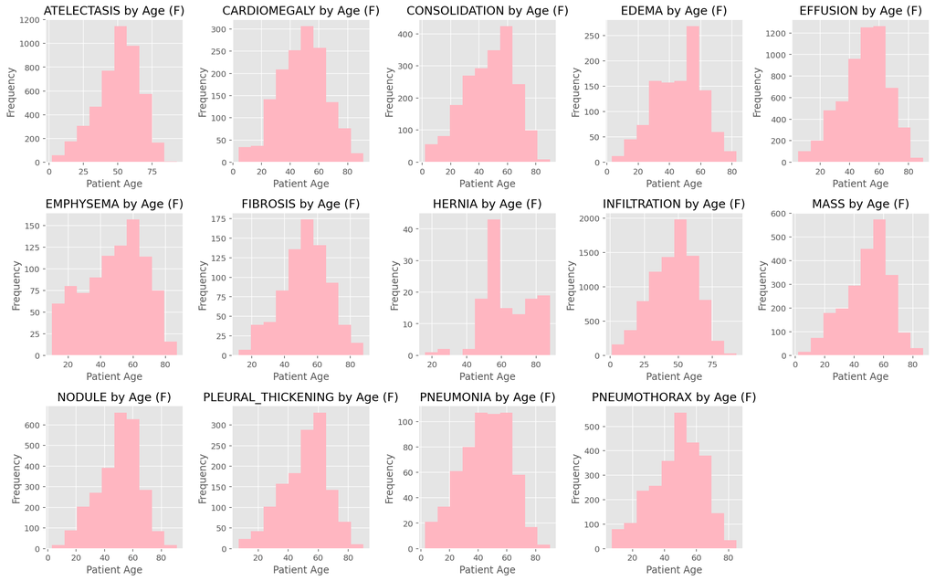

```python
## Age distribution for each disease for the female population.
fig = plt.subplots(figsize = (16, 10))
for i, label in enumerate(labels):
    plt.subplot(3, 5, i+1)
    plt.subplots_adjust(hspace=1.)
    plt.hist(age_cut_off[(age_cut_off[label]==1.) & (age_cut_off['Patient Gender'] == 'F')]['Patient Age'], color="lightpink")
    plt.xlabel('Patient Age')
    plt.ylabel('Frequency')
    plt.title('%s by Age (F)' % label.upper())
    plt.tight_layout()
plt.savefig('./out/EDA_Age_Distribution_for_Each_Disease_F.png', dpi=300)
```

Here, we see *almost* identical age distributions for both genders (of Pneumonia).

## Distribution of Each Disease by View Position

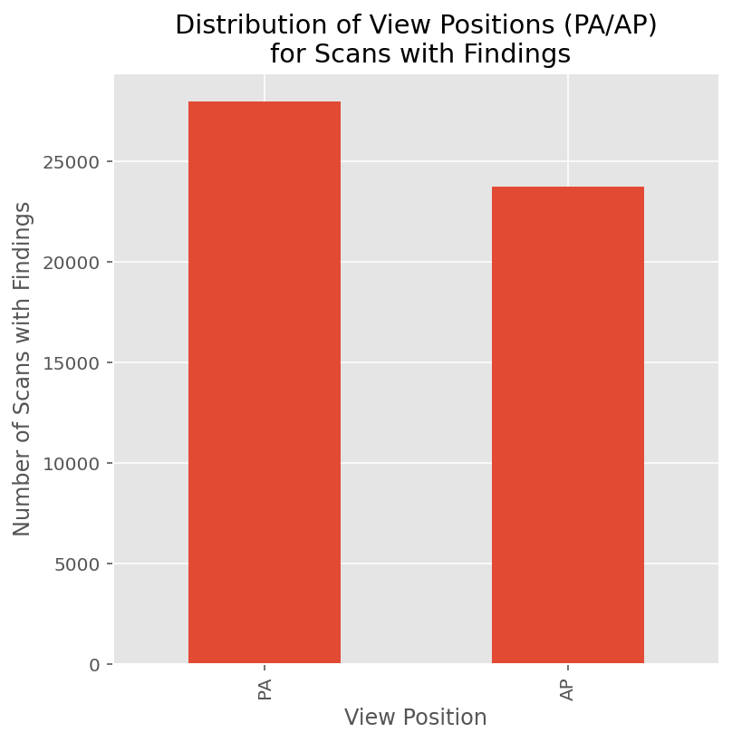

```python
# Exploring by view position.
plt.figure(figsize=(6, 6))
all_xray_df[all_xray_df['Finding Labels'] != 'No Finding']['View Position'].value_counts().plot(kind='bar')
plt.title('Distribution of View Positions (PA/AP)\n for Scans with Findings')
plt.xlabel('View Position')
plt.ylabel('Number of Scans with Findings')
plt.savefig('./out/EDA_Distribution_of_View_Positions.png', dpi=300)
plt.show()
```

Here, we see *more* PA view positions acquired than APs.

> PA stands for Posterior-Anterior, and AP stands for Anterior-Posterior.

### Distribution of View Positions for Each Disease

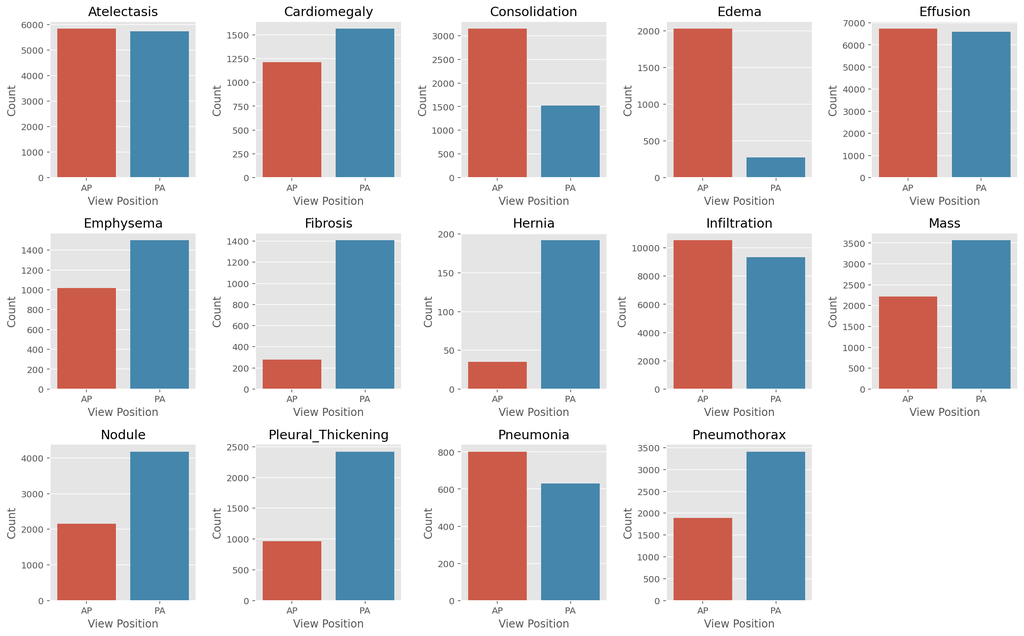

```python
fig = plt.subplots(figsize=(16, 10))
for i, label in enumerate(labels):
    plt.subplot(3, 5, i+1)
    plt.subplots_adjust(hspace=1.)
    ax = sns.countplot(
        x='View Position',
        data=all_xray_df[all_xray_df[label]==1],
        order=['AP', 'PA'])
    plt.title(label)
    plt.ylabel('Count')
    plt.title(label)
    plt.tight_layout()
plt.savefig('./out/EDA_Distribution_by_View_Positions_for_Each_Disease.png', dpi=300)
```

```python
for label in labels:
    AP_view_pos = all_xray_df[all_xray_df['View Position']=='AP'][label].sum()
    PA_view_pos = all_xray_df[all_xray_df['View Position']=='PA'][label].sum()

    if AP_view_pos < PA_view_pos:
        print('%s: has more PA view compared to AP views.' % (label.upper()))

    elif AP_view_pos > PA_view_pos:
        print('%s: has fewer PA views compared to AP views.' % (label.upper()))

    else:
        print('%s: Equally found in both view positions.' % (label.upper()))
```

```
ATELECTASIS: has fewer PA views compared to AP views.
CARDIOMEGALY: has more PA view compared to AP views.
CONSOLIDATION: has fewer PA views compared to AP views.
EDEMA: has fewer PA views compared to AP views.
EFFUSION: has fewer PA views compared to AP views.
EMPHYSEMA: has more PA view compared to AP views.
FIBROSIS: has more PA view compared to AP views.
HERNIA: has more PA view compared to AP views.
INFILTRATION: has fewer PA views compared to AP views.
MASS: has more PA view compared to AP views.
NODULE: has more PA view compared to AP views.
PLEURAL_THICKENING: has more PA view compared to AP views.
PNEUMONIA: has fewer PA views compared to AP views.
PNEUMOTHORAX: has more PA view compared to AP views.
```

## Number of Pneumonia Cases

```python
## How many cases do exist?
print('Number of Pneumonia cases in the data: %d' % all_xray_df['Pneumonia'].sum())
```

```
Number of Pneumonia cases in the data: 1431
```

### How many Non-Pneumonia cases are there?

```python
non_pneumonia_count = 0

for label in labels:
    if label != 'Pneumonia':
        print(f'Number of %s cases in the data: %d' % (label.upper(), all_xray_df[label].sum()))
        non_pneumonia_count += all_xray_df[label].sum()

print(f'Total cases: %d' % non_pneumonia_count)
```

```
Number of ATELECTASIS cases in the data: 11559
Number of CARDIOMEGALY cases in the data: 2776
Number of CONSOLIDATION cases in the data: 4667
Number of EDEMA cases in the data: 2303
Number of EFFUSION cases in the data: 13317
Number of EMPHYSEMA cases in the data: 2516
Number of FIBROSIS cases in the data: 1686
Number of HERNIA cases in the data: 227
Number of INFILTRATION cases in the data: 19894
Number of MASS cases in the data: 5782
Number of NODULE cases in the data: 6331
Number of PLEURAL_THICKENING cases in the data: 3385
Number of PNEUMOTHORAX cases in the data: 5302
Total cases: 79745
```

## Distribution of Diseases Comorbid with Pneumonia

```python
all_xray_df[all_xray_df.Pneumonia==1][labels].sum()
```

```
Atelectasis            262.0
Cardiomegaly            41.0
Consolidation          123.0
Edema                  340.0
Effusion               269.0
Emphysema               23.0
Fibrosis                11.0
Hernia                   3.0
Infiltration           605.0
Mass                    71.0
Nodule                  70.0
Pleural_Thickening      48.0
Pneumonia             1431.0
Pneumothorax            41.0
dtype: float64
```

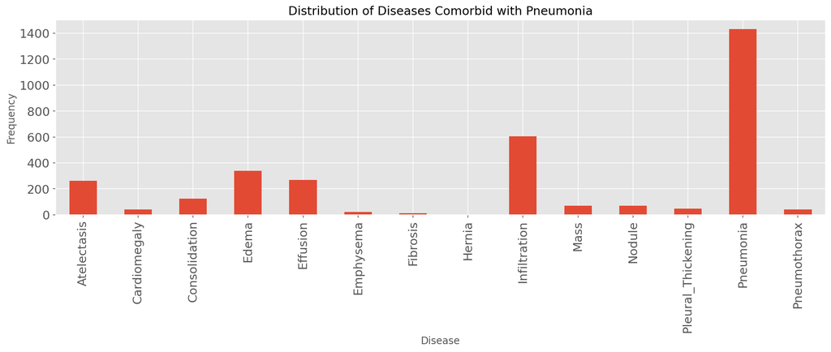

```python
plt.figure(figsize=(14, 6))
all_xray_df[all_xray_df.Pneumonia==1][labels].sum().plot(kind='bar', fontsize='x-large')
plt.xlabel('Disease')
plt.ylabel('Frequency')
plt.title('Distribution of Diseases Comorbid with Pneumonia')
plt.tight_layout()
plt.savefig('./out/EDA_Distribution_of_Diseases_Comorbid_with_Pneumonia.png', dpi=300)
plt.show()
```

We can see that **Infiltration** (being the top), **Ddema**, **Effusion**, **Atelectasis** and **Consolidation** are indeed the top diseases that comorbid with Pneumonia. Furthermore, these top five diseases *should* have *balanced* representations in both training and validation data sets.

## Number of Diseases per Patient

```python
diseases_per_patient = all_xray_df.groupby(['Patient ID'])[labels].sum()
diseases_per_patient['disease_count'] = diseases_per_patient.astype(bool).sum(axis=1)

diseases_per_patient.sample(10, random_state=RND_STATE)
```

| Patient ID | Atelectasis | Cardiomegaly | Consolidation | Edema | Effusion | Emphysema | Fibrosis | Hernia | Infiltration | Mass | Nodule | Pleural_Thickening | Pneumonia | Pneumothorax | disease_count |
| --- | --- | --- | --- | --- | --- | --- | --- | --- | --- | --- | --- | --- | --- | --- | --- |
| 12681 | 8.0 | 1.0 | 2.0 | 1.0 | 5.0 | 0.0 | 0.0 | 0.0 | 4.0 | 0.0 | 3.0 | 0.0 | 0.0 | 0.0 | 7 |
| 13125 | 3.0 | 3.0 | 1.0 | 0.0 | 3.0 | 0.0 | 0.0 | 0.0 | 3.0 | 0.0 | 0.0 | 0.0 | 0.0 | 0.0 | 5 |
| 29707 | 0.0 | 0.0 | 0.0 | 0.0 | 0.0 | 0.0 | 0.0 | 0.0 | 0.0 | 0.0 | 0.0 | 0.0 | 0.0 | 0.0 | 0 |
| 24851 | 0.0 | 0.0 | 0.0 | 0.0 | 0.0 | 0.0 | 0.0 | 0.0 | 0.0 | 0.0 | 0.0 | 0.0 | 0.0 | 0.0 | 0 |
| 12409 | 0.0 | 0.0 | 0.0 | 0.0 | 0.0 | 0.0 | 1.0 | 0.0 | 0.0 | 0.0 | 0.0 | 0.0 | 0.0 | 0.0 | 1 |
| 21447 | 0.0 | 0.0 | 0.0 | 0.0 | 0.0 | 0.0 | 0.0 | 0.0 | 0.0 | 0.0 | 0.0 | 0.0 | 0.0 | 0.0 | 0 |
| 19589 | 0.0 | 0.0 | 0.0 | 0.0 | 0.0 | 0.0 | 0.0 | 0.0 | 0.0 | 0.0 | 0.0 | 0.0 | 0.0 | 0.0 | 0 |
| 6113 | 0.0 | 0.0 | 0.0 | 0.0 | 0.0 | 0.0 | 0.0 | 0.0 | 0.0 | 2.0 | 0.0 | 0.0 | 0.0 | 0.0 | 1 |
| 11943 | 0.0 | 0.0 | 0.0 | 0.0 | 0.0 | 0.0 | 0.0 | 0.0 | 0.0 | 2.0 | 1.0 | 0.0 | 0.0 | 0.0 | 2 |
| 1434 | 0.0 | 0.0 | 0.0 | 0.0 | 0.0 | 0.0 | 0.0 | 0.0 | 0.0 | 0.0 | 0.0 | 0.0 | 0.0 | 0.0 | 0 |

```python
all_xray_df['Total Disease Count'] = all_xray_df[all_labels].sum(axis=1)
all_xray_df['Total Disease Count'][all_xray_df['No Finding']==1.] = 0

print('Average number of diseases per patient: {}'.format(
    np.round(all_xray_df['Total Disease Count'].mean(), 2)))
```

```
Average number of diseases per patient: 0.72
```

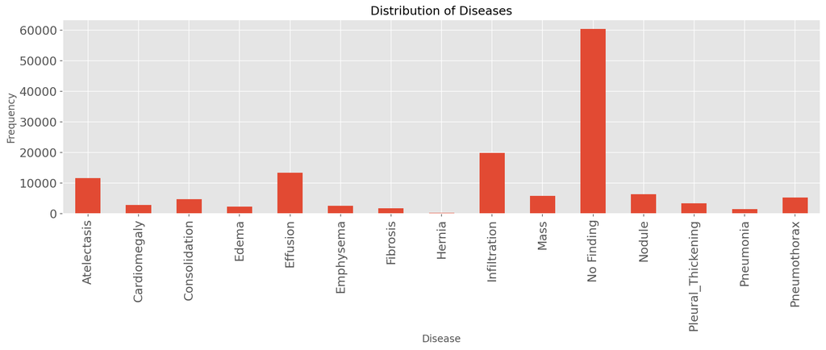

```python
plt.figure(figsize=(14, 6))
all_xray_df[all_labels].sum().plot(kind='bar', fontsize='x-large')
plt.xlabel('Disease')
plt.ylabel('Frequency')
plt.title('Distribution of Diseases')
plt.tight_layout()
plt.savefig('./out/EDA_Distribution_of_Diseases.png', dpi=300)
plt.show()
```

```python
(all_xray_df['No Finding']==0).sum()
```

```
51759
```

```python
disease_count = diseases_per_patient['disease_count'].unique()
disease_count
```

```
array([ 3,  0,  2,  1, 10,  4,  8,  5,  6,  7, 11,  9, 12, 13],
      dtype=int64)
```

```python
patient_count = [diseases_per_patient[diseases_per_patient['disease_count']==item].count()[0] for item in disease_count]
patient_count
```

```
[1638, 16403, 2908, 6742, 84, 1087, 205, 707, 518, 335, 28, 139, 7, 4]
```

```python
for num_diseases, num_patients in sorted(zip(disease_count, patient_count)):
    print('%d patients (i.e., %s of the population) suffer from %d condition(s)' % (
        num_patients,
        str(format(100.*num_patients/np.sum(patient_count), '.2f')) + "%",
        num_diseases))
```

```
16403 patients (i.e., 53.25% of the population) suffer from 0 condition(s)
6742 patients (i.e., 21.89% of the population) suffer from 1 condition(s)
2908 patients (i.e., 9.44% of the population) suffer from 2 condition(s)
1638 patients (i.e., 5.32% of the population) suffer from 3 condition(s)
1087 patients (i.e., 3.53% of the population) suffer from 4 condition(s)
707 patients (i.e., 2.30% of the population) suffer from 5 condition(s)
518 patients (i.e., 1.68% of the population) suffer from 6 condition(s)
335 patients (i.e., 1.09% of the population) suffer from 7 condition(s)
205 patients (i.e., 0.67% of the population) suffer from 8 condition(s)
139 patients (i.e., 0.45% of the population) suffer from 9 condition(s)
84 patients (i.e., 0.27% of the population) suffer from 10 condition(s)
28 patients (i.e., 0.09% of the population) suffer from 11 condition(s)
7 patients (i.e., 0.02% of the population) suffer from 12 condition(s)
4 patients (i.e., 0.01% of the population) suffer from 13 condition(s)
```

We see more than half of the patient population in the data are not diagnosed with any diseases (53.25% of the population) [i.e., identified with the ‘No Findings’ tag]. Meanwhile, others seem to suffer from multiple (cooccurring) conditions like the case with 4 patients (0.01% of the population) having 13 conditions reported, and another case with 7 patients (0.02% of the population) having 12 conditions reported.

> Since more than half of the population have reported 0 diseases, we believe it is necessary for us to **drop some of the records** for the purpose of creating a more reliable data set for training and validating any network architecture of choice.

## Pixel-level Assessments of the Imaging Data

```python
sample_labels = np.unique(list(chain(*data_sample['Finding Labels'].map(lambda x: x.split('|')).tolist())))
sample_labels
```

```
array(['Atelectasis', 'Cardiomegaly', 'Consolidation', 'Edema',
       'Effusion', 'Emphysema', 'Fibrosis', 'Hernia', 'Infiltration',
       'Mass', 'No Finding', 'Nodule', 'Pleural_Thickening', 'Pneumonia',
       'Pneumothorax'], dtype='<U18')
```

```python
for name in sample_labels:
    data_sample[name] = data_sample['Finding Labels'].map(lambda finding: 1. if name in finding else 0)
    print(f'%s: %d'%(name.upper(), int(data_sample[name].sum())))
```

```
ATELECTASIS: 508
CARDIOMEGALY: 141
CONSOLIDATION: 226
EDEMA: 118
EFFUSION: 644
EMPHYSEMA: 127
FIBROSIS: 84
HERNIA: 13
INFILTRATION: 967
MASS: 284
NO FINDING: 3044
NODULE: 313
PLEURAL_THICKENING: 176
PNEUMONIA: 62
PNEUMOTHORAX: 271
```

```
Pixel-level assessments of ATELECTASIS cases:
```

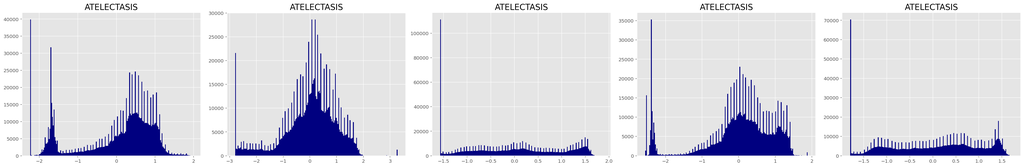

```
Pixel-level assessments of CARDIOMEGALY cases:
```

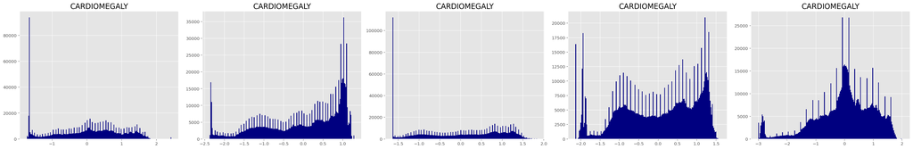

```
Pixel-level assessments of CONSOLIDATION cases:
```

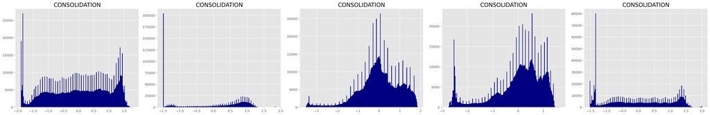

```
Pixel-level assessments of EDEMA cases:
```

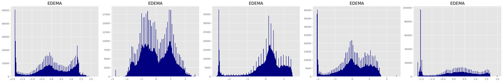

```
Pixel-level assessments of EFFUSION cases:
```

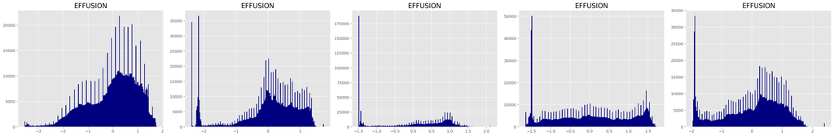

```
Pixel-level assessments of EMPHYSEMA cases:
```

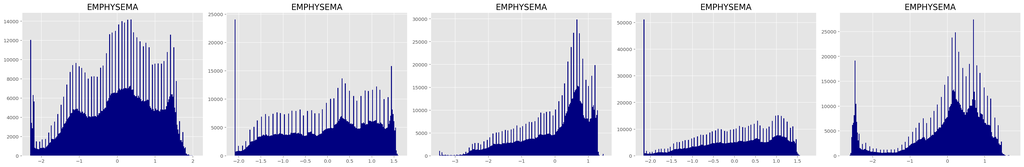

```
Pixel-level assessments of FIBROSIS cases:
```

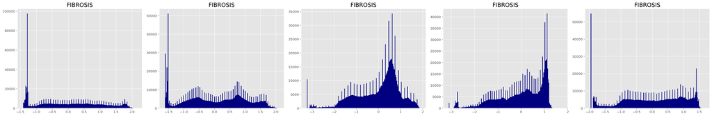

```
Pixel-level assessments of HERNIA cases:
```

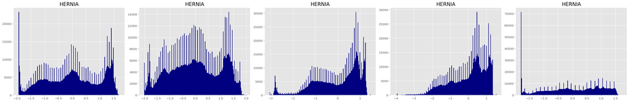

```
Pixel-level assessments of INFILTRATION cases:
```

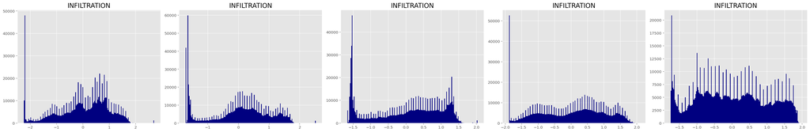

```
Pixel-level assessments of MASS cases:
```

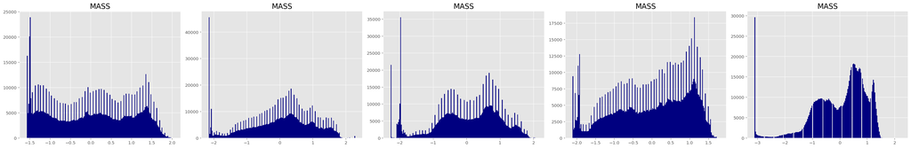

```
Pixel-level assessments of NO FINDING cases:
```

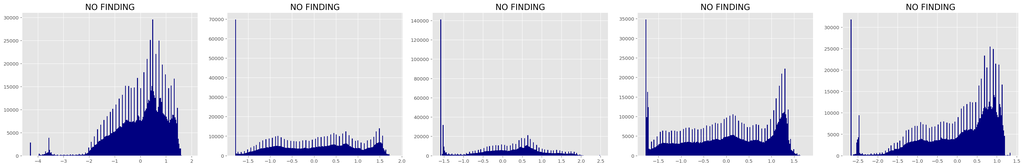

```
Pixel-level assessments of NODULE cases:
```

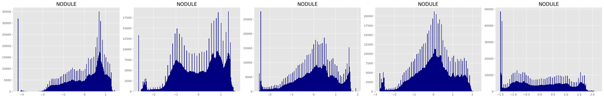

```
Pixel-level assessments of PLEURAL_THICKENING cases:
```

[3 more figures not shown]

```python
for disease in sample_labels:

    print('Pixel-level assessments of {} cases:'.format(disease.upper()))

    # Current image path from dir.
    img_path = data_sample[data_sample["Finding Labels"]==disease].sample(5, random_state=RND_STATE)["path"]

    # Plot by image path.
    plt.figure(figsize=(30, 5))
    for i in range(len(img_path)):
        plt.subplot(1, len(img_path), i+1).set_title(disease.upper(), fontsize='xx-large')
        var = plt.imread(img_path.iloc[i])
        plt.hist(((var-np.mean(var))/np.std(var)).ravel(), bins=200, color='navy')
        # plt.xlim(-3, 3)
    plt.tight_layout()
    plt.savefig('./out/EDA_Pixel_level_Assessments_of_{}_Cases.png'.format(disease), dpi=300)
    plt.show()
```

From the plots above we see that Pneumonia exhibited similar pixel-intensity distributions with other diseases, such as Consolidation, Edema, and others.

> One factor that might be impacting the qualities of each Xray scan obtained is the Viewing Positions of the scans, and how they can affect the assessments made by radiologists in accurately identifying diseases in the data (see [this link](https://www.radiologymasterclass.co.uk/tutorials/chest/chest_quality/chest_xray_quality_projection) for reference).

```python
## We are done with this notebook!
import IPython
app = IPython.Application.instance()
app.kernel.do_shutdown(True)
```

```
{'status': 'ok', 'restart': True}
```